# Выбор локации для скважины

Допустим, вы работаете в добывающей компании «ГлавРосГосНефть». Нужно решить, где бурить новую скважину.

Шаги для выбора локации:

- В избранном регионе ищут месторождения, для каждого определяют значения признаков;
- Строят модель и оценивают объём запасов;
- Выбирают месторождения с самым высокими оценками значений. Количество месторождений зависит от бюджета компании и стоимости разработки одной скважины;
- Прибыль равна суммарной прибыли отобранных месторождений.

## Загрузка и подготовка данных

### Загрузка данных

```python
# Инсталляция библиотек
!pip install -q phik==0.11.1
!pip install -U scikit-learn;
```

```python
# Импорт библиотек
import os
import pandas as pd
import numpy as np

from scipy import stats
from phik import resources, report

from sklearn.model_selection import train_test_split
from sklearn.model_selection import GridSearchCV
from sklearn.pipeline import Pipeline
from sklearn.compose import ColumnTransformer
from sklearn.preprocessing import (
    StandardScaler,
    MinMaxScaler,
    RobustScaler
)
from sklearn.linear_model import LinearRegression
from sklearn.metrics import mean_squared_error


import matplotlib.pyplot as plt
import seaborn as sns
```

```python
# Объвление констант
RANDOM_STATE = 42
TEST_SIZE = 0.25
```

```python
# Пути к файлам с данными
geo_data_0 = '/datasets/geo_data_0.csv'
geo_data_1 = '/datasets/geo_data_1.csv'
geo_data_2 = '/datasets/geo_data_2.csv'
```

```python
# Чтение файла с данными
if os.path.exists(geo_data_0):
    df_gd_0=pd.read_csv(geo_data_0, index_col='id')
else:
    print('Не нейден путь к файлу')
```

```python
# Вывод общей информации о данных
df_gd_0.info()
```

```
<class 'pandas.core.frame.DataFrame'>
Index: 100000 entries, txEyH to 1CWhH
Data columns (total 4 columns):
 #   Column   Non-Null Count   Dtype
---  ------   --------------   -----
 0   f0       100000 non-null  float64
 1   f1       100000 non-null  float64
 2   f2       100000 non-null  float64
 3   product  100000 non-null  float64
dtypes: float64(4)
memory usage: 3.8+ MB
```

```python
# Вывод первых строк
df_gd_0.head(5)
```

| id | f0 | f1 | f2 | product |
| --- | --- | --- | --- | --- |
| txEyH | 0.705745 | -0.497823 | 1.221170 | 105.280062 |
| 2acmU | 1.334711 | -0.340164 | 4.365080 | 73.037750 |
| 409Wp | 1.022732 | 0.151990 | 1.419926 | 85.265647 |
| iJLyR | -0.032172 | 0.139033 | 2.978566 | 168.620776 |
| Xdl7t | 1.988431 | 0.155413 | 4.751769 | 154.036647 |

```python
# Чтение файла с данными
if os.path.exists(geo_data_1):
    df_gd_1=pd.read_csv(geo_data_1, index_col='id')
else:
    print('Не нейден путь к файлу')
```

```python
# Вывод общей информации о данных
df_gd_1.info()
```

```
<class 'pandas.core.frame.DataFrame'>
Index: 100000 entries, kBEdx to relB0
Data columns (total 4 columns):
 #   Column   Non-Null Count   Dtype
---  ------   --------------   -----
 0   f0       100000 non-null  float64
 1   f1       100000 non-null  float64
 2   f2       100000 non-null  float64
 3   product  100000 non-null  float64
dtypes: float64(4)
memory usage: 3.8+ MB
```

```python
# Вывод первых строк
df_gd_1.head(5)
```

| id | f0 | f1 | f2 | product |
| --- | --- | --- | --- | --- |
| kBEdx | -15.001348 | -8.276000 | -0.005876 | 3.179103 |
| 62mP7 | 14.272088 | -3.475083 | 0.999183 | 26.953261 |
| vyE1P | 6.263187 | -5.948386 | 5.001160 | 134.766305 |
| KcrkZ | -13.081196 | -11.506057 | 4.999415 | 137.945408 |
| AHL4O | 12.702195 | -8.147433 | 5.004363 | 134.766305 |

```python
# Чтение файла с данными
if os.path.exists(geo_data_2):
    df_gd_2=pd.read_csv(geo_data_2, index_col='id')
else:
    print('Не нейден путь к файлу')
```

```python
# Вывод общей информации о данных
df_gd_2.info()
```

```
<class 'pandas.core.frame.DataFrame'>
Index: 100000 entries, fwXo0 to V9kWn
Data columns (total 4 columns):
 #   Column   Non-Null Count   Dtype
---  ------   --------------   -----
 0   f0       100000 non-null  float64
 1   f1       100000 non-null  float64
 2   f2       100000 non-null  float64
 3   product  100000 non-null  float64
dtypes: float64(4)
memory usage: 3.8+ MB
```

```python
# Вывод первых строк
df_gd_2.head(5)
```

| id | f0 | f1 | f2 | product |
| --- | --- | --- | --- | --- |
| fwXo0 | -1.146987 | 0.963328 | -0.828965 | 27.758673 |
| WJtFt | 0.262778 | 0.269839 | -2.530187 | 56.069697 |
| ovLUW | 0.194587 | 0.289035 | -5.586433 | 62.871910 |
| q6cA6 | 2.236060 | -0.553760 | 0.930038 | 114.572842 |
| WPMUX | -0.515993 | 1.716266 | 5.899011 | 149.600746 |

### Предобработка

```python
print('В датафрейме "df_gd_0" {} полных дубликатов'.format(df_gd_0.duplicated().sum()))
print('В датафрейме "df_gd_1" {} полных дубликатов'.format(df_gd_1.duplicated().sum()))
print('В датафрейме "df_gd_2" {} полных дубликатов'.format(df_gd_2.duplicated().sum()))
```

```
В датафрейме "df_gd_0" 0 полных дубликатов
В датафрейме "df_gd_1" 0 полных дубликатов
В датафрейме "df_gd_2" 0 полных дубликатов
```

Проверяю уникальность id во всех трех датасетах и их характеристики. Для этого попарно объединю все три таблицы внутренним объединением с использованием суффиксов. Это позоволит увидеть данные по одинаковым id.

```python
# внутреннее объединение таблиц
df_gd_0.join(df_gd_1, how='inner', rsuffix='_gd_1', lsuffix='_gd_0').sort_values(by='id')
```

| id | f0_gd_0 | f1_gd_0 | f2_gd_0 | product_gd_0 | f0_gd_1 | f1_gd_1 | f2_gd_1 | product_gd_1 |
| --- | --- | --- | --- | --- | --- | --- | --- | --- |
| CXJ2r | 1.799663 | 0.152615 | 2.308270 | 124.783815 | 4.595329 | -1.967882 | 4.000767 | 107.813044 |
| L1Fdm | -0.870625 | 0.216046 | 6.551127 | 99.473405 | -3.346138 | 1.878476 | 0.004355 | 3.179103 |
| Mp3uM | 0.233182 | 0.999516 | 1.626957 | 109.425501 | 6.109864 | -6.680806 | 4.995256 | 134.766305 |
| Q64YW | 0.453692 | 0.851595 | 1.483317 | 137.265232 | 3.005548 | -0.243063 | 5.000265 | 134.766305 |
| Y2udP | 1.226808 | -0.482702 | 7.197720 | 178.864963 | 12.544203 | 5.897907 | 1.007743 | 26.953261 |
| g3RRG | 1.256835 | -0.594468 | 2.258115 | 36.909351 | 5.884971 | -3.853958 | 5.000735 | 134.766305 |
| gnA83 | 0.874183 | 0.658348 | 4.315275 | 78.952516 | 13.842436 | -12.362831 | 4.003258 | 107.813044 |
| it2OW | -0.649660 | 0.966137 | 7.852383 | 152.939409 | -7.472182 | -14.802085 | 4.005783 | 110.992147 |
| mpZhE | 1.050752 | 0.001206 | 3.015799 | 102.323401 | 11.206881 | -2.291883 | 1.003807 | 26.953261 |
| pGQRI | 0.042350 | -0.052613 | 2.241901 | 168.331029 | -5.171681 | -0.546409 | 3.002864 | 84.038886 |

```python
# внутреннее объединение таблиц
df_gd_0.join(df_gd_2, how='inner', rsuffix='_gd_2', lsuffix='_gd_0').sort_values(by='id')
```

| id | f0_gd_0 | f1_gd_0 | f2_gd_0 | product_gd_0 | f0_gd_2 | f1_gd_2 | f2_gd_2 | product_gd_2 |
| --- | --- | --- | --- | --- | --- | --- | --- | --- |
| 2tyMi | 0.576679 | -0.411140 | -3.725859 | 69.292672 | -1.789602 | -1.359044 | -4.840745 | 145.901447 |
| 5ssQt | -1.005117 | 0.268726 | -0.407822 | 53.206029 | -0.651825 | 0.782415 | 2.690636 | 120.108761 |
| G6k8A | -0.332671 | 0.873613 | 0.056776 | 59.356289 | 3.021943 | 2.091350 | 2.325737 | 81.922702 |
| H2jd8 | -0.095755 | 0.549838 | 4.798969 | 121.587791 | -0.882244 | 0.102113 | 5.132965 | 97.736331 |
| LhkAh | -0.016588 | 0.311455 | 5.752433 | 100.077127 | -1.011388 | -1.422994 | 0.167327 | 97.289509 |
| PyNp5 | 0.800617 | -0.423276 | -0.262853 | 37.280078 | -1.248973 | -1.246669 | -0.538638 | 122.021857 |
| Suyut | 1.034755 | 0.211378 | 5.166985 | 134.183249 | 0.730034 | 0.998910 | 0.673342 | 51.978338 |
| TXPOv | -0.614415 | 0.669327 | 4.392560 | 111.029432 | -1.714714 | 0.545975 | 6.907380 | 109.685043 |
| eVdPR | 0.948962 | 0.470545 | 4.841681 | 114.217840 | -3.325910 | 0.212653 | -2.172340 | 61.323206 |
| i2csb | 1.876060 | 0.130102 | 3.916158 | 178.191619 | 0.395736 | -1.039466 | 3.262824 | 136.079194 |
| kpKGs | 1.984545 | 0.356201 | -0.876743 | 53.006141 | 0.391595 | 0.520890 | 0.935081 | 91.558464 |
| lFHA5 | 0.825315 | -0.415530 | 1.316067 | 145.287376 | 1.143130 | 1.528147 | 2.717799 | 84.144358 |
| rAJA6 | 0.763807 | -0.256567 | -2.539103 | 36.295666 | 1.426039 | 1.262731 | 1.915009 | 80.927100 |
| scFN4 | 1.209207 | -0.491543 | 0.871066 | 82.239907 | 2.198203 | 0.733283 | 10.562272 | 153.719681 |
| tgOl6 | 1.242237 | -0.545994 | -1.070228 | 52.566338 | -6.077439 | -1.366449 | 1.858951 | 153.001240 |
| uSye4 | 1.452571 | -0.452693 | -1.800189 | 79.717634 | -0.066172 | 2.543996 | -0.054049 | 141.345070 |
| wqgPo | 2.009877 | -0.119927 | 5.254332 | 72.798085 | 0.052461 | 1.424025 | 0.085541 | 10.686576 |

```python
# внутреннее объединение таблиц
df_gd_1.join(df_gd_2, how='inner', rsuffix='_gd_2', lsuffix='_gd_1').sort_values(by='id')
```

| id | f0_gd_1 | f1_gd_1 | f2_gd_1 | product_gd_1 | f0_gd_2 | f1_gd_2 | f2_gd_2 | product_gd_2 |
| --- | --- | --- | --- | --- | --- | --- | --- | --- |
| D8TNs | -0.646266 | 3.667055 | 1.006161 | 30.132364 | 0.280382 | 0.061393 | 4.887870 | 114.943876 |
| TAqwC | -13.045712 | -13.056006 | 0.007640 | 3.179103 | -0.176382 | -0.503558 | 1.877303 | 38.618695 |
| g2I86 | 17.818406 | 2.946716 | 0.991640 | 26.953261 | -1.616730 | 1.110380 | 4.226968 | 107.940639 |
| uMqiK | 2.734183 | -3.102346 | -0.002654 | 0.000000 | -1.772509 | 0.152085 | -0.422541 | 119.682928 |

Одинаковые id скважин встречаются во всех трех датасетах, но судя по их характеристикам, это разные скважины.

### Исследовательский анализ

Анализирую распределения признаков в датасетах:

```python
# настройки оформления диаграмм библиотеки seaborn
sns.set_style('darkgrid')
sns.set(font_scale=1.3)
```

```
Распределение входящих признаков в трех регионах нефтедобычи
```

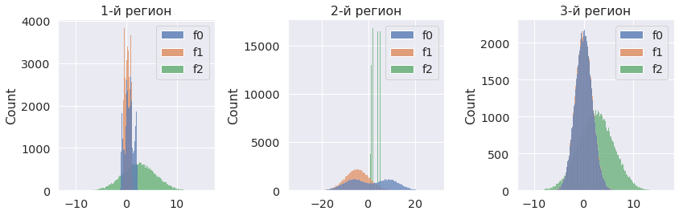

```python
# гистограммы
print('Распределение входящих признаков в трех регионах нефтедобычи')
f, axs = plt.subplots(1, 3, figsize=(12, 4))
sns.histplot(data=df_gd_0[['f0','f1','f2']], ax=axs[0])
axs[0].set_title("1-й регион")
sns.histplot(data=df_gd_1[['f0','f1','f2']], ax=axs[1])
axs[1].set_title("2-й регион")
sns.histplot(data=df_gd_2[['f0','f1','f2']], ax=axs[2])
axs[2].set_title("3-й регион")
f.tight_layout();
```

На гистограммах видно что признаки f0, f1, f2 в разных датасетах имеют разное распределение. В первом датасете только признак f2 имеет распределение, близкое к нормальному. Во втором датасете - только признак f1. В третьем датасете все три признака распределены нормально. Признак f2 во втором датасете распределен неравномерно. Строю для него отдельную гистрограмму:

```
Распределение признака f2 во втором регионе нефтедобычи
```

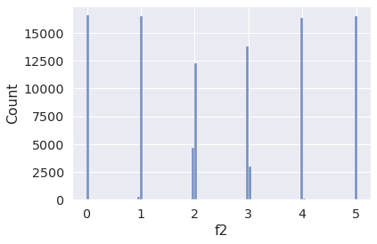

```python
# гистограмма
print('Распределение признака f2 во втором регионе нефтедобычи')
sns.histplot(df_gd_1.f2, bins=100);
```

Видно что значения признака f2 во втором датасете группируются вокруг целых значений от 0 до 5.

Строю гистограммы для целевого признака в трех датасетах (в трех регионах).

```
Распределение целевого признака в трех регионах нефтедобычи
```

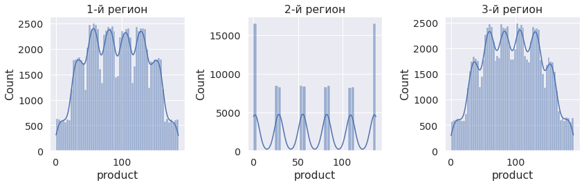

```python
# гистограммы
print('Распределение целевого признака в трех регионах нефтедобычи')
f, axs = plt.subplots(1, 3, figsize=(12, 4))
sns.histplot(data=df_gd_0, x="product", kde=True, ax=axs[0])
axs[0].set_title("1-й регион")
sns.histplot(data=df_gd_1, x="product", kde=True, ax=axs[1])
axs[1].set_title("2-й регион")
sns.histplot(data=df_gd_2, x="product", kde=True, ax=axs[2])
axs[2].set_title("3-й регион")
f.tight_layout();
```

Видно что распределение целевого признака в первом и третьем регионе похожи, а во втором датасете имеет такое же рапределение как у признака f2 - значения группируются вокруг целых значений от 0 до 5. При этом во всех датасетах наблюдается по 6 явных пиков в распределении целевого признака.

Проверяю у каких признаков есть выборосы с помощью диаграммы "ящик с усами"

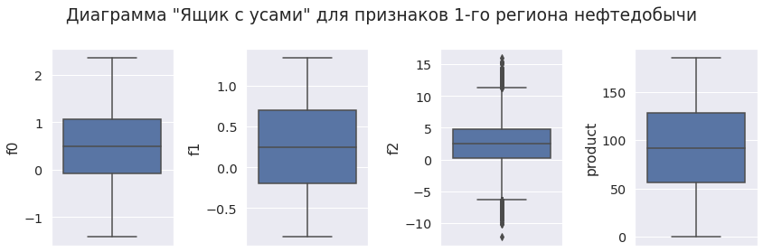

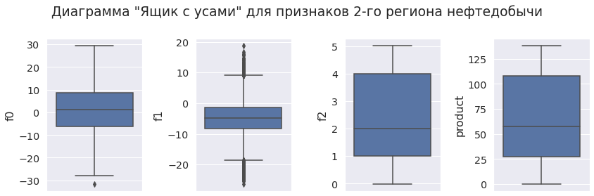

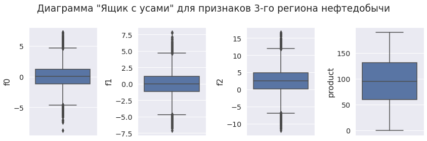

```python
counter = 1
for i in [df_gd_0, df_gd_1, df_gd_2]:
    f, axs = plt.subplots(1, 4, figsize=(12, 4))
    f.suptitle('Диаграмма "Ящик с усами" для признаков '+ str(counter) + '-го региона нефтедобычи')
    counter +=1
    sns.boxplot(data=i, y='f0', ax=axs[0])
    sns.boxplot(data=i, y='f1', ax=axs[1])
    sns.boxplot(data=i, y='f2', ax=axs[2])
    sns.boxplot(data=i, y='product', ax=axs[3])
    f.tight_layout();
```

Видно что выбросы существуют у всех признаков, распределение которых приближается к нормальному.  
С помощью диаграмм рассеяния выявляю линейную зависимость между признаками.

```
Диаграмма "pairplot" для признаков 1-го региона нефтедобычи
```

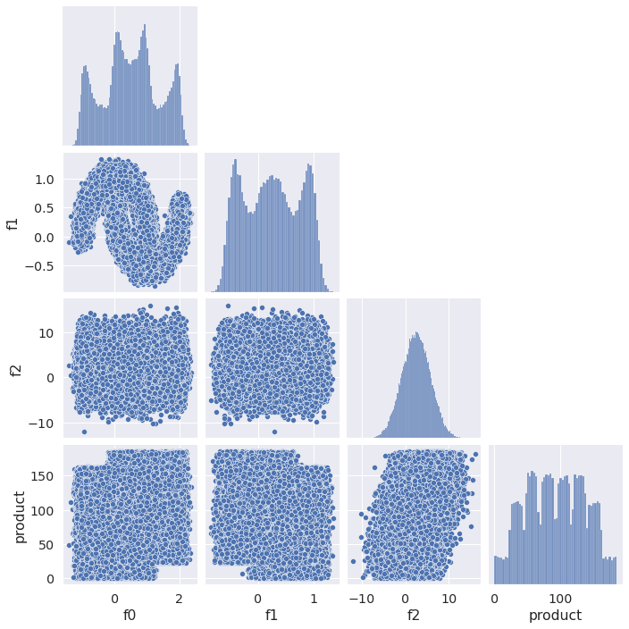

```python
print('Диаграмма "pairplot" для признаков 1-го региона нефтедобычи')
ax = sns.pairplot(df_gd_0,  corner=True)
```

```
Диаграмма "pairplot" для признаков 2-го региона нефтедобычи
```

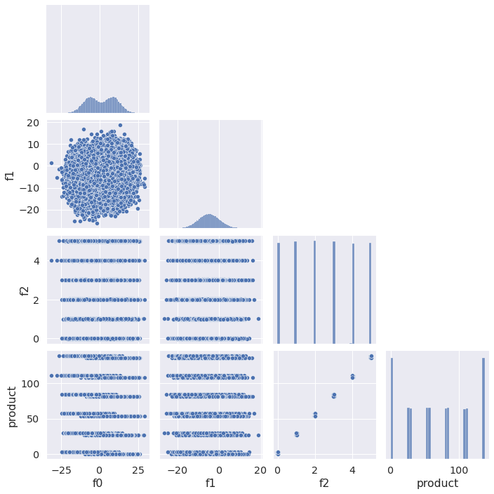

```python
print('Диаграмма "pairplot" для признаков 2-го региона нефтедобычи')
sns.pairplot(df_gd_1,  corner=True);
```

```
Диаграмма "pairplot" для признаков 3-го региона нефтедобычи
```

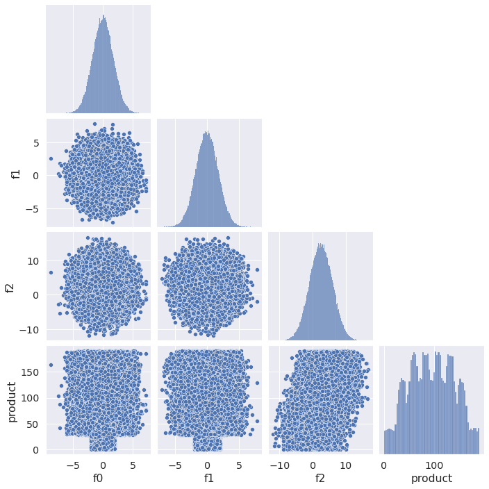

```python
print('Диаграмма "pairplot" для признаков 3-го региона нефтедобычи')
sns.pairplot(df_gd_2,  corner=True);
```

Явная линейная зависимость присутствует только во втором датасете между целевым признаком и признаком f2  
С помощью коэффициента корреляции оцениваю силу зависимости признаков.

```
Матрицы корреляций для датасетов трех регионов нефтедобычи
```

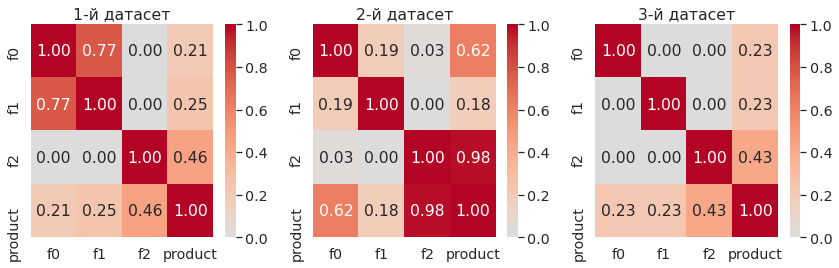

```python
# heatmap (seaborn) на основании матрицы корреляций библиотеки phik.
print('Матрицы корреляций для датасетов трех регионов нефтедобычи')
f, axs = plt.subplots(1, 3, figsize=(12, 4))
sns.heatmap(df_gd_0.phik_matrix(interval_cols=['f0', 'f1', 'f2', 'product'],\
        bins={'f0':20, 'f1':20, 'f2':20, 'product':20}), cmap='coolwarm',\
        ax=axs[0], center=0, annot=True, fmt='.2f')
axs[0].set_title("1-й датасет")
sns.heatmap(df_gd_1.phik_matrix(interval_cols=['f0', 'f1', 'f2', 'product'],\
        bins={'f0':20, 'f1':20, 'f2':20, 'product':20}), cmap='coolwarm',\
        ax=axs[1], center=0, annot=True, fmt='.2f')
axs[1].set_title("2-й датасет")
sns.heatmap(df_gd_2.phik_matrix(interval_cols=['f0', 'f1', 'f2', 'product'],\
        bins={'f0':20, 'f1':20, 'f2':20, 'product':20}), cmap='coolwarm',\
        ax=axs[2], center=0, annot=True, fmt='.2f')
axs[2].set_title("3-й датасет")
f.tight_layout();
```

heatmap с коэффициентами корреляции подтверждает выводы, сделанные с помощью диаграммы рассеяния:

- Во втором датасете есть сильная зависимость (0.98) между целевым признаком и f2
- В первом датасете есть значительная зависимость между f1 и f0 (мультиколлинеарность), это может плохо повлиять на обучение модели линейной регрессии
- В первом и третьем датасетах зависимость целевого признака от входящих не наблюдается, а такая зависимость является необходимым условием для обучения модели линейной регресии.

### Выводы загрузки и анализа данных

Все данные соответствуют описанию.  
Пропущенных данных нет.  
Наименования столбцов корректные.  
id скважин преобразованы в индексы.  
Тип данных - float64. Тип данных везде корректный.  
Полных дубликатов в данных нет.  
id скважин не уникальны в пределах всех трех датасетов, но это разные скважины, судя по их характеристикам.

На гистограммах видно что признаки f0, f1, f2 в разных датасетах имеют разное распределение. В первом датасете только признак f2 имеет распределение, близкое к нормальному. Во втором датасете - только признак f1. В третьем датасете все три признака распределены нормально. Все признаки с нормальным распределением имеют выбросы.

Диаграммы heatmap и рассеяния позволяют сделать следующие выводы:

- Во втором датасете есть сильная зависимость (0.98) между целевым признаком и f2
- В первом датасете есть значительная зависимость между f1 и f0 (мультиколлинеарность), это может плохо повлиять на обучение модели линейной регрессии
- В первом и третьем датасетах зависимость целевого признака от входящих не наблюдается, а такая зависимость является необходимым условием для обучения модели линейной регресии.

### Подготовка данных

Разбиваю каждый из трех датасетов на обучающую и валидационную выборки в соотношении 75:25.

```python
df_gd_0_train, df_gd_0_valid = train_test_split(df_gd_0, test_size=TEST_SIZE, random_state=RANDOM_STATE)
print(df_gd_0_train.shape, df_gd_0_valid.shape)
```

```
(75000, 4) (25000, 4)
```

```python
df_gd_1_train, df_gd_1_valid = train_test_split(df_gd_1, test_size=TEST_SIZE, random_state=RANDOM_STATE)
print(df_gd_1_train.shape, df_gd_1_valid.shape)
```

```
(75000, 4) (25000, 4)
```

```python
df_gd_2_train, df_gd_2_valid = train_test_split(df_gd_2, test_size=TEST_SIZE, random_state=RANDOM_STATE)
print(df_gd_2_train.shape, df_gd_2_valid.shape)
```

```
(75000, 4) (25000, 4)
```

## Обучение и проверка модели

### Функция для масштабирования данных и обучения модели в пайплайне

```python
def train_model(df_oil):
    X_train = df_oil.drop(['product'], axis=1)
    y_train = df_oil['product']
# создаём списки с названиями признаков
    num_columns = ['f0', 'f1', 'f2']
# создаём общий пайплайн для подготовки данных
    data_preprocessor = ColumnTransformer(
        [
            ('num', StandardScaler(), num_columns)
        ],
        remainder='passthrough'
    )
# создаём итоговый пайплайн: подготовка данных и модель
    pipe_final= Pipeline(
        [
            ('preprocessor', data_preprocessor),
            ('models', LinearRegression())
        ]
    )
    param_grid = {
        'preprocessor__num': [
            StandardScaler(),
            MinMaxScaler(),
            RobustScaler(),
            'passthrough'
        ]
    }
    grid = GridSearchCV(
        pipe_final,
        param_grid=param_grid,
        cv=5,
        scoring='neg_root_mean_squared_error',
        n_jobs=-1
    )
    grid.fit(X_train, y_train)

    print('Лучшая модель и её параметры:\n\n', grid.best_estimator_)
    print(f'Лучшее значение метрики  RMSE: {grid.best_score_ * -1}')
    return grid
```

### Предсказание на валидационной выборке и оценка моделей

Обучаю модель на первом датасете:

```python
grid_0 = train_model(df_gd_0_train)
```

```
Лучшая модель и её параметры:

 Pipeline(steps=[('preprocessor',
                 ColumnTransformer(remainder='passthrough',
                                   transformers=[('num', StandardScaler(),
                                                  ['f0', 'f1', 'f2'])])),
                ('models', LinearRegression())])
Лучшее значение метрики  RMSE: 37.67200536313506
```

Сохраняю правильные ответы и предсказания на валидационной выборке для первого датасета:

```python
df_res_0 = pd.DataFrame(zip(df_gd_0_valid['product'], grid_0.predict(df_gd_0_valid)),columns=['fact','pred'])
```

```python
df_res_0.sample(3)
```

|  | fact | pred |
| --- | --- | --- |
| 22067 | 128.322443 | 92.918718 |
| 23984 | 67.620431 | 79.577185 |
| 12922 | 152.791583 | 125.785016 |

Обучаю модель на втором датасете:

```python
grid_1 = train_model(df_gd_1_train)
```

```
Лучшая модель и её параметры:

 Pipeline(steps=[('preprocessor',
                 ColumnTransformer(remainder='passthrough',
                                   transformers=[('num', StandardScaler(),
                                                  ['f0', 'f1', 'f2'])])),
                ('models', LinearRegression())])
Лучшее значение метрики  RMSE: 0.8904559629285671
```

Сохраняю правильные ответы и предсказания на валидационной выборке для второго датасета:

```python
df_res_1 = pd.DataFrame(zip(df_gd_1_valid['product'], grid_1.predict(df_gd_1_valid)), columns=['fact','pred'])
```

```python
df_res_1.sample(3)
```

|  | fact | pred |
| --- | --- | --- |
| 1738 | 84.038886 | 83.587103 |
| 11327 | 137.945408 | 138.171775 |
| 11319 | 84.038886 | 82.659146 |

Обучаю модель на третьем датасете:

```python
grid_2 = train_model(df_gd_2_train)
```

```
Лучшая модель и её параметры:

 Pipeline(steps=[('preprocessor',
                 ColumnTransformer(remainder='passthrough',
                                   transformers=[('num', StandardScaler(),
                                                  ['f0', 'f1', 'f2'])])),
                ('models', LinearRegression())])
Лучшее значение метрики  RMSE: 40.02698159997838
```

Сохраняю правильные ответы и предсказания на валидационной выборке для третьего датасета:

```python
df_res_2 = pd.DataFrame(zip(df_gd_2_valid['product'], grid_2.predict(df_gd_2_valid)), columns=['fact','pred'])
```

```python
df_res_2.sample(3)
```

|  | fact | pred |
| --- | --- | --- |
| 21617 | 172.388882 | 111.298504 |
| 2151 | 155.835884 | 113.339650 |
| 18253 | 29.134192 | 125.369542 |

```python
print(f'Метрика RMSE для первого региона: {mean_squared_error(df_res_0.fact, df_res_0.pred, squared=False):.2f}')
print(f'Метрика RMSE для второго региона: {mean_squared_error(df_res_1.fact, df_res_1.pred, squared=False):.2f}')
print(f'Метрика RMSE для третьего региона: {mean_squared_error(df_res_2.fact, df_res_2.pred, squared=False):.2f}')
```

```
Метрика RMSE для первого региона: 37.76
Метрика RMSE для второго региона: 0.89
Метрика RMSE для третьего региона: 40.15
```

### Анализ остатков

Рассчитываю остатки модели для первого региона:

```python
residuals1 = df_res_0.fact - df_res_0.pred
```

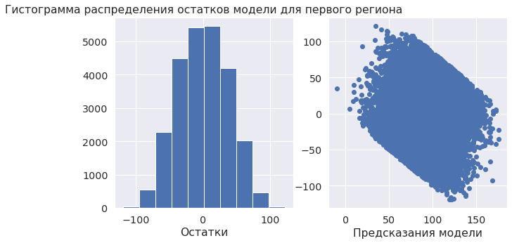

```python
# гистограмма частотности распределения и диаграмму рассеяния
fig, axes = plt.subplots(nrows=1, ncols=2, figsize=(10,5))
axes[0].hist(residuals1)
axes[0].set_title('Гистограмма распределения остатков модели для первого региона')
axes[0].set_xlabel('Остатки')

axes[1].scatter(x=df_res_0.pred, y=residuals1)
axes[1].set_xlabel('Предсказания модели')
```

Рассчитываю остатки модели для второго региона:

```python
residuals2 = df_res_1.fact - df_res_1.pred
```

[figure not shown]

```python
# гистограмма частотности распределения и диаграмму рассеяния
fig, axes = plt.subplots(nrows=1, ncols=2, figsize=(10,5))
axes[0].hist(residuals1)
axes[0].set_title('Гистограмма распределения остатков модели для второго региона')
axes[0].set_xlabel('Остатки')

axes[1].scatter(x=df_res_1.pred, y=residuals2)
axes[1].set_xlabel('Предсказания модели')
```

Рассчитываю остатки модели для третьего региона:

```python
residuals3 = df_res_2.fact - df_res_2.pred
```

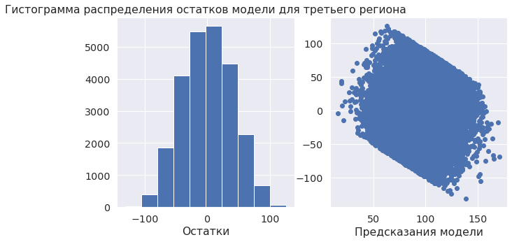

```python
# гистограмма частотности распределения и диаграмму рассеяния
fig, axes = plt.subplots(nrows=1, ncols=2, figsize=(10,5))
axes[0].hist(residuals3)
axes[0].set_title('Гистограмма распределения остатков модели для третьего региона')
axes[0].set_xlabel('Остатки')

axes[1].scatter(x=df_res_2.pred, y=residuals3)
axes[1].set_xlabel('Предсказания модели')
```

### Выводы

```python
print(f'Средний запас скважины в первом регионе: фактический - {df_res_0.fact.mean():.3f},\
    предсказанный - {df_res_0.pred.mean():.3f}')
print(f'Средний запас скважины во втором регионе: фактический - {df_res_1.fact.mean():.3f},\
    предсказанный - {df_res_1.pred.mean():.3f}')
print(f'Средний запас скважины в третьем регионе: фактический - {df_res_2.fact.mean():.3f},\
    предсказанный - {df_res_2.pred.mean():.3f}')
```

```
Средний запас скважины в первом регионе: фактический - 92.326,    предсказанный - 92.399
Средний запас скважины во втором регионе: фактический - 68.725,    предсказанный - 68.713
Средний запас скважины в третьем регионе: фактический - 95.151,    предсказанный - 94.771
```

Метрика RMSE для всех трех регионов на валидационных данных близка к метрике модели, соответственно 37.76, 0.89, и 40.15 для первого, второго и третьего регионов.

## Подготовка к расчёту прибыли

Сохраняю все ключевые значения для расчетов по уловию задачи:

- При разведке региона исследуют 500 точек, из которых с помощью машинного обучения выбирают 200 лучших для разработки.
- Бюджет на разработку скважин в регионе — 10 млрд рублей.
- При нынешних ценах один баррель сырья приносит 450 рублей дохода. Доход с каждой единицы продукта составляет 450 тыс. рублей, поскольку объём указан в тысячах баррелей.
- После оценки рисков нужно оставить лишь те регионы, в которых вероятность убытков меньше 2.5%.

```python
# Объвление констант
POINTS_COUNT = 500
BEST_POINTS_COUNT = 200
DEVELOPMENT_BUDGET = 10_000_000_000
UNIT_INCOME = 450000
LOSS_PROBABILITY = 2.5
```

```python
print(f'Достаточный объём сырья для безубыточной разработки новой скважины {DEVELOPMENT_BUDGET/UNIT_INCOME/BEST_POINTS_COUNT:.2f} единицы продукта')
```

```
Достаточный объём сырья для безубыточной разработки новой скважины 111.11 единицы продукта
```

```python
print('Если не выбирать лучшие скважины с помощью машинного обучения, а взять в разработку любые,',
      'то исходя из их средней продуктивности для безубыточной разработки :')
print(f'в первом регионе понадобится разработать {DEVELOPMENT_BUDGET/UNIT_INCOME/df_res_0.fact.mean():.0f} скважин')
print(f'во втором регионе понадобится разработать {DEVELOPMENT_BUDGET/UNIT_INCOME/df_res_1.fact.mean():.0f} скважин')
print(f'в третьем регионе понадобится разработать {DEVELOPMENT_BUDGET/UNIT_INCOME/df_res_2.fact.mean():.0f} скважин')
print('Но по условиям задачи можно взять в разработку только 200 скважин')
```

```
Если не выбирать лучшие скважины с помощью машинного обучения, а взять в разработку любые, то исходя из их средней продуктивности для безубыточной разработки :
в первом регионе понадобится разработать 241 скважин
во втором регионе понадобится разработать 323 скважин
в третьем регионе понадобится разработать 234 скважин
Но по условиям задачи можно взять в разработку только 200 скважин
```

Функция для расчёта прибыли по выбранным скважинам и предсказаниям модели:

```python
def revenue(target, probabilities, count):
    probs_sorted = probabilities.sort_values(ascending=False)
    selected = target[probs_sorted.index][:count]
    return UNIT_INCOME * selected.sum()-DEVELOPMENT_BUDGET
```

## Расчёт прибыли и рисков

```python
def bootstrap_1000(df):
    state = np.random.RandomState(12345)

    values = []
    for i in range(1000):
        target_subsample = df.fact.sample(n=POINTS_COUNT, replace=True, random_state=state)
        pred_subsample = df.pred[target_subsample.index]

        values.append(revenue(target_subsample, pred_subsample, BEST_POINTS_COUNT))

    values = pd.Series(values)

    mean =  values.mean()
    print(f'Средняя прибыль от {BEST_POINTS_COUNT} лучших скважин: {mean :,.0f} руб.')

    confidence_interval = stats.t.interval(0.95, len(values)-1, values.mean(), values.sem())

    print(f'95%-ый доверительный интервал средней прибыли: {confidence_interval}')
    loss = stats.percentileofscore(values,0)
    print(f'Риск убытков составляет {loss:,.1f} %')
    if(loss>LOSS_PROBABILITY):
        print('Регион не подходит для разработки')
    else:
        print('Регион подходит для разработки')
```

```python
print('Для первого региона:')
bootstrap_1000(df_res_0)
```

```
Для первого региона:
Средняя прибыль от 200 лучших скважин: 435,933,772 руб.
95%-ый доверительный интервал средней прибыли: (418761103.88268757, 453106440.39463663)
Риск убытков составляет 6.1 %
Регион не подходит для разработки
```

```python
print('Для второго региона:')
bootstrap_1000(df_res_1)
```

```
Для второго региона:
Средняя прибыль от 200 лучших скважин: 489,661,254 руб.
95%-ый доверительный интервал средней прибыли: (476234866.0816714, 503087642.7418335)
Риск убытков составляет 1.1 %
Регион подходит для разработки
```

```python
print('Для третьего региона:')
bootstrap_1000(df_res_2)
```

```
Для третьего региона:
Средняя прибыль от 200 лучших скважин: 403,687,928 руб.
95%-ый доверительный интервал средней прибыли: (386206714.79285574, 421169140.93142116)
Риск убытков составляет 7.1 %
Регион не подходит для разработки
```

### Выводы и рекомендации

Для разработки подходит только второй регион, так как вероятность уыбтков в нем менее 2.5%  
Характеристики этого региона:

- Средняя прибыль от 200 лучших скважин: 489,661,254 руб.
- 95%-ый доверительный интервал средней прибыли: (476234866.081673, 503087642.741837)
- Риск убытков составляет 1.1 %